# Chapter 10

Randy

9/12/2021

# Chapter 10: Linear Model with Fixed Effects and Correlated Errors

violation of iid assumptions

- from studies collecting measures over time, i.e., in a longitudinal fashion
- in designs which involve clustering or grouping, e.g., cluster-randomization clinical trials;
- in studies collecting spatially correlated data,

a class of more general LMs that allow relaxing the assumptions of independence and variance homogeneity

LMs with fixed effects and correlated residual errors for grouped data, or simply as LMs for correlated data

$$\begin{split}
& \pmb y_i = \pmb X_i\pmb \beta + \pmb \epsilon_i\ \ \ \ (10.1)\\
& \pmb y_i \equiv \{ _c\ y_{ij}\}_{j=1}^{n_i} \\
& \pmb \epsilon_i \equiv \{ _c\ \epsilon_{ij}\}_{j=1}^{n_i}\\
& \pmb X_i\equiv \{r\ \pmb x_i^{(m)} \}_{m=1}^{p} \equiv \{_r\ \{_c\ x_{ij} \}_{j=1}^{n_i} \}_{m=1}^{p}\\
& \pmb \epsilon_i \sim \mathcal N_{n_i}(\pmb 0,\ \pmb {\mathbb R}_i)\\
& \pmb {\mathbb R}_i = \sigma^2\pmb R_i \ \ \ \ (10. 5)\\
& E[y_{ij}] \equiv \mu_{ij} = \pmb x_{ij}'\pmb \beta \ \ \ \ (10.6)\\
& Var[\pmb y_i] = \sigma^2 \pmb R_i \ \ \ \ (10.7)
\end{split}$$

## 10.3 Details of Model Specification

- The LM with correlated errors is not identifiable in its most general form.
- The nonuniqueness of the representation (10.5) and because the model potentially involves too many unknown parameters related to the variance-covariance matrix of the residual errors $\pmb \epsilon_i$.
- A solution is to represent the matrices as functions of a small number of parameters.

$\pmb R_i = \pmb \Lambda_i \pmb C_i \pmb \Lambda_i$

$$\{\pmb \Lambda_i\}_{j,j} \equiv \lambda_{i_{j,j}} = \lambda (\mu_{ij}, \pmb \delta; \pmb v_{ij}) \ \ \ \ (10.9)$$

$\pmb \delta$ is a vector of variance parameters, and $\pmb v_{ij}$ is a vector of (known) variance covariates. Moreover, we assume that the matrix $\pmb C_i$ is specified using a set of parameters $\pmb \rho$.

$$\pmb R_i(\mu_{ij},\ \pmb \theta_R;\ \pmb v_{ij}) = \pmb \Lambda_i(\mu_{ij},\ \pmb \delta;\ \pmb v_{ij})\pmb C_i(\pmb \rho)\pmb \Lambda_i(\mu_{ij},\ \pmb \delta;\ \pmb v_{ij}) \ \ \ \ (10.10)$$

$\pmb \theta_R \equiv (\pmb \delta',\ \pmb \rho')$. However, to simplify notation, we will often suppress the use of $\pmb \theta_R$, $\mu_{ij}$, and $\pmb v_{ij}$ in formulae, unless specified otherwise.

### 10.3.1 Variance Structure

$$Var(\epsilon_{ij}) = \sigma^2 \lambda^2(\mu _{ij},\ \pmb \delta;\ \pmb v_{ij}) \ \ \ \ (10.11)$$

- The decomposition (10.10) allows for the use of both mean-independent and mean-dependent variance functions (Table 7.1).
- However, as mentioned in, e.g., Sects. 7.4 and 7.8, the application of variance functions that depend on the mean value requires the use of more advanced estimation and inferential approaches.

$$Var(\epsilon_{ij}) = \sigma^2 \lambda^2(\pmb \delta;\ \pmb v_{ij}). (10.12)$$

### 10.3.2 Correlation Structure

the matrix $\pmb C_i$ is specified by assuming that the correlation coefficient between two residual errors, $\epsilon_{ij}$ and $\epsilon_{ij'}$, corresponding to two observations from the same group $i$, is given by

$$Corr(\epsilon_{ij},\ \epsilon_{ij'}) = h[d(\pmb t_{ij},\ \pmb t_{ij'}), \pmb \rho] \ \ \ \ (10.13)$$

where $\pmb \rho$ is a vector of correlation parameters, $d(\pmb t_{ij},\ \pmb t_{ij'})$ is a distance function of vectors of position variables $\pmb t_{ij}$ and $\pmb t_{ij'}$ corresponding to, respectively, $\epsilon_{ij}$ and $\epsilon_{ij'}$, and $h(·,\ ·)$ is a continuous function with respect to $\pmb \rho$, such that it takes values between $-1$ and $1$, and $h(0,\ \pmb\rho) \equiv 1$.

By assuming various distances and correlation functions, a variety of correlation structures can be obtained.

`corCompSymm` a compound-symmetry structure corresponding to uniform correlation. `corAR1` corresponding to an autoregressive process of order 1. `corARMA` corresponding to an autoregressive moving average (ARMA) process. `corCAR1` corresponding to a continuous-time autoregressive process. `corSymm` a general correlation matrix (unstructured). `corExp` exponential spatial correlation. `corGaus` Gaussian spatial correlation. `corLin` linear spatial correlation. `corRatio` rational quadratic spatial correlation. `corSpher` spherical spatial correlation.

The correlation structures can be classified into two main groups:

1. “Serial” structures (`corCompSymm`, `corAR1`, `corARMA`, `corCAR1`, `corSymm`), corresponds to the correlation structures which are defined in the context of time-series or longitudinal data.
2. “Spatial” structures (`corExp`, `corGaus`, `corLin`, `corRatio`, `corSpher`), corresponding to correlation structures which are defined in the context of spatial data.

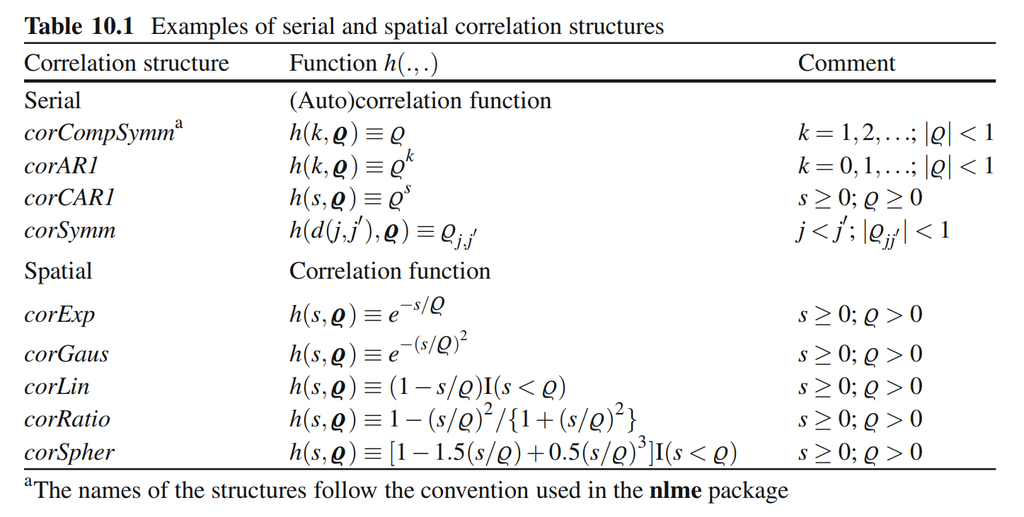

### 10.3.3 Serial Correlation Structures

Note that, for time-series data, the function $h(.,\ .)$ is often called an autocorrelation function.

the simplest serial correlation structure, compound-symmetry (`corCompSymm`), assumes a constant correlation between all within-group residual errors.

This means that $Corr(\epsilon_{ij},\ \epsilon_{ij'}) = \rho\ \ \ \ (10.14)$, which corresponds to (10.13) upon defining, for $j \neq j'$ and $k = 1,\ 2,\ ...$, $h(k,\ \rho) \equiv \rho \ \ \ \ (10.15)$

A more advanced example of a serial correlation structure, `corARMA`, is obtained from an ARMA process.

The process corresponds to longitudinal observations, for which a current observation can be expressed as a sum of:

1. a linear combination of, say $p$, previous observations;
2. a linear combination of, say $q$, meanzero, independent and identically distributed residual random errors from previous observations;
3. a mean-zero, independent residual random error for the current measurement.

The structure is described by $p+q$ parameters. Unlike the correlation structures shown in Table 10.1, the (auto)correlation function of an ARMA process cannot be expressed by a simple, closed-form expression, but it is defined by a recursive relation

### 10.3.4 Spatial Correlation Structures

$Corr(\epsilon_{ij},\ \epsilon_{ij'}) = \exp (-s_{ij,\ ij'}/\rho) \ \ \ \ (10.16)$ where $s_{ij,\ ij'} = d(\pmb t_{ij},\ \pmb t_{ij'})$ is a real number equal to the distance between the two position vectors $\pmb t_{ij}$ and $t_{ij'}$ corresponding to observations $j$ and $j'$, respectively, from the same group $i$. The corresponding function $h$ is defined as $h(s,\ \rho) \equiv \exp(-s/ \rho) \ \ \ \ (10.17)$

- The most natural choice is the Euclidean distance, i.e., the square root of the sum, over all dimensions, of the squares of distances.
- The "maximum (or Tchebyshev) metric, i.e., the maximum, over all dimensions, of the absolute differences;
- Manhattan (or “city block”, “taxicab”) distance, i.e., the sum, over all dimensions, of the absolute differences. Note that these three choices correspond to the $L_2$, $L_\infty$ (Cantrell 2000), and $L_1$ metrics, respectively.

It is worth noting that in the spatial correlation literature, the parameter %, used in Table 10.1 for the spatial structures, is referred to as range. spatial correlation functions are continuous and monotonically nonincreasing.

This characteristic reflects a commonly observed feature of the data that observations being further apart are correlated to a lesser degree.

This requirement can be relaxed by including the so-called **nugget effect**, an abrupt change in correlation at small distances (discontinuity at zero), which can be defined by the condition that $h(s,\ \rho)$ tends to $1 - \rho_0$, with $\rho_0 \in (0,\ 1)$, when $s$ tends to $0$.

In other words, a discontinuity at $s = 0$ can be allowed for. Consequently, a correlation function $h_{\rho_0} (·,\ ·)$ containing a nugget effect can be obtained from any continuous spatial correlation function $h(·,\ ·)$ by defining

$$h_{\rho_0} (s,\ \pmb \rho) \equiv
\begin{cases}
(1 - \rho_0)h(s, \pmb\rho) & if\ s > 0,\\
1 & if\ s = 0
\end{cases}
\ \ \ \ (10.18)$$

Instead of the correlation function, spatial correlation structures are often represented by the semivariogram function or simply semivariogram (Cressie 1991).

For the cases considered in this book, the semivariogram function can be defined as the complement of the correlation function, that is,

$$\gamma(s,\ \pmb \rho) \equiv 1 - h(s,\ \pmb \rho) \ \ \ \ (10.19)$$

$$\gamma_{\rho_0} (s,\ \pmb \rho) \equiv
\begin{cases}
\rho_0 + (1 - \rho_0)\gamma(s, \pmb\rho) & if\ s > 0,\\
0 & if\ s = 0
\end{cases}
\ \ \ \ (10.20)$$

Consequently, $\gamma(s,\ \pmb\rho)$ tends to $\rho_0$, with $\rho_0 \in (0,\ 1)$, when $s$ tends to $0$.

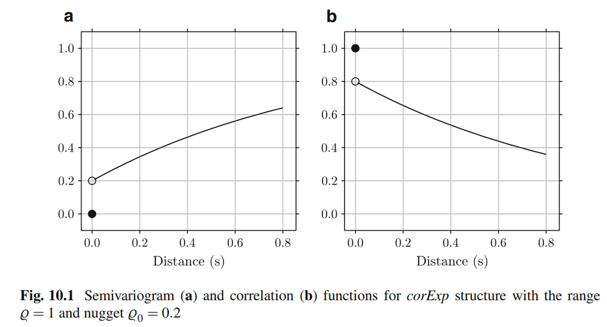

## 10.4 Estimation

focus on the estimation approaches for simpler models defined with the use of variance functions from the $<\delta>$-group, which do not depend on the mean value (see Table 7.2)

### 10.4.1 Weighted Least Squares

Similarly to models with known variance weights presented in Sect. 7.2.1, the model with known matrices $\pmb R_i$ does not pose any additional computational difficulties

$$\pmb W^{1/2}_i \pmb y_i = \pmb W^{1/2}_i \pmb X_i \pmb \beta + \pmb W_i^{1 /2} \pmb \epsilon_i \ \ \ \ (10.21)$$
$\pmb W_i^{1/2} \equiv \pmb R^{-1/2}_i$, where $\pmb R_i^{1/2}$ is the upper-triangular Cholesky decomposition of $\pmb R^{-1}_i$, i.e., $\pmb R^{-1}_i = (\pmb R^{- 1/2}_i)' \pmb R^{- 1/2}_i$, we transform the model with correlated residual errors back to an LM with independent, homoscedastic errors.

Note that, in the transformed model, the linearity with respect to $\pmb \beta$ is maintained.

Moreover, the variance-covariance matrix of the transformed residual error vector is $Var(\pmb W_i^{1/2} \pmb \epsilon_i) = \pmb W_i^{1/2} Var(\epsilon_i) (\pmb W_i^{1/2})' = \pmb R^{-1/2}_i(\sigma ^2 \pmb R_i)(\pmb R^{- 1/2}_i)' = \sigma^2 \pmb I_{n_i}$.

The estimates of $\pmb \beta$ are obtained by the minimization, with respect to $\pmb \beta$, of a weighted residual sum of squares

$$\sum_{i=1}^n (\pmb y_i - \pmb X_i\pmb\beta)' \pmb W_i(\pmb y_i - \pmb X_i \pmb \beta) \ \ \ \ (10.22)$$

Explicit formulae for WLS estimators for $\pmb \beta$ and $\sigma^2$, built upon (7.18) and (7.19), are as follows:

$$\pmb {\hat \beta}_{WLS}
\equiv \Bigg(\sum^N_{i=1} \pmb X'_i \pmb W_i \pmb X_i\Bigg)^{-1}
\sum^N_{i=1}\pmb X'_i \pmb W_i \pmb y_i \ \ \ \ (10.23)\\
\sigma^2_{WLS} \equiv \frac 1 {n - p}
\sum^N_{i=1} (y_i - \pmb X_i \pmb {\hat \beta}_{WLS})' \pmb W_i (y_i - \pmb X_i\pmb {\hat \beta}_{WLS}) \ \ \ \ (10.24)$$

where $\pmb W_i \equiv \pmb R^{- 1}_i$ and $n = \sum^N_{i=1} n_i$.

## 10.4.2 Likelihood-Based Estimation

$$l_{Full}(\pmb \beta,\ \sigma^2,\ \pmb \theta_R) \equiv
- \frac n 2 \log(\sigma^2)- \frac 1 2 \sum^N_{i=1} \log[det(\pmb R_i)]
- \frac 1 {2\sigma^2} \sum_N^{i=1} (\pmb y_i - \pmb X_i\pmb \beta)' \pmb R_{i}^{-1}
(\pmb y_i - \pmb X_i\pmb \beta) \ \ \ \ (10.25)$$

Note that we presented unconstrained parameterizations for selected correlation structures.

The transformations, which preserve the positive-definiteness of the matrix $\pmb C_i$ are relatively simple for the compound-symmetry and the autoregressiveof-order-1 structures, while it is more complex for a general structure.

We need to keep in mind that for some correlation structures, especially for those described by multiple parameters, there is no guarantee that such transformations exist.

### 10.4.4 Uncertainty in Parameter Estimation

$$\widehat {Var} (\hat \beta) \equiv \hat \sigma^2 \Big(\sum^N_{i=1}
\pmb X_i' \hat {\pmb R}^{-1}_i \pmb X_i\Big)^{-1}\ \ \ \ (10.38)$$

## Model Diagnostics

### 10.5.1 Residual Diagnostics

Thus, the comments regarding residual diagnostics for the LM for independent observation with heterogeneous variance, provided in Sect. 7.5, apply here as well. Consequently, Pearson residuals (see Sect. 7.5.1) are more useful for checking for, e.g., outlying observations.

Therefore, the Pearson residuals are well suited to investigate whether an appropriate correlation structure was used in the model.

$$\frac 1 {2N(s)} \sum^N_{i=1} \sum_{d(\pmb t_{ij},\ \pmb t_{ij'})=s}(r_{ij} - r_{ij'})^2 \ \ \ \ (10.39)$$

$$\frac 1 {0.457 + 0.494/N(s)}
\Bigg(
\frac 1 {2N(s)} \sum^N_{i=1} \sum_{d(\pmb t_{ij},\ \pmb t_{ij'})=s}|r_{ij} - r_{ij'}|^{1/2} \Bigg)^4\ \ \ \ (10.40)$$

Thus, for example, even if we studentize the residuals (Sect. 4.6.1), the overall Q-Q plots, based on all estimated residuals, are not appropriate for checking the normality of the residual random error.

A possible solution is to obtain approximately independent residuals using the transformation of the residuals based on the Cholesky decomposition of the matrix $\pmb R_i$ (see Sect. 4.5.2).

- That is, to use the transformed residuals $(\sigma \pmb U'_i)^{-1} \pmb {\hat \epsilon}_i$, where the upper-triangular matrix $\pmb U_i$ is obtained from the Cholesky decomposition of the matrix $\pmb R_i$, i.e., $\pmb R_i = \pmb U'_i \pmb U_i$ (Schabenberger 2004).
- The vector of the transformed residuals should be approximately normally distributed with mean $\pmb 0$ and variance-covariance matrix equal to an identity matrix.
- That is, the elements of the vector should be uncorrelated and follow the standard normal distribution.
- Note that, in the `nlme` package, these transformed residuals are referred to as normalized residuals. We will use this term in the remainder of our book

### 10.5.2 Influence Diagnostics

After identifying influential observations using likelihood displacement, Cook’s distance, similar to that given in (4.26), may be used to determine whether a particular observation affects estimation of $\pmb \beta$.

## 10.6 Inference and Model Selection

The comments about the use of the REML in the construction of the LR test apply here as well.

The second approach, based on the information criteria, is used when the hypothesis about qR cannot be expressed in the way that it would lead to two nested models. In this case, we can use the information criteria like AIC or BIC (Sect. 4.7.2) to select the model that seems to better fit the data.

The information criteria can be also used for the more general problem of model selection, i.e., for discrimination between nonnested models, which differ both in the variance-covariance and the mean structures. In this case, the criteria are applied in a way similar to the one described in Sect. 7.7.

Obviously, irrespectively of the approach chosen for the model reduction or selection, the fit of the final model should be formally checked using the residual diagnostic methods.

Confidence intervals for the variance-covariance parameters s and d can be obtained by considering a normal-distribution approximation to the distribution of the ML- or REML-based estimator of a transformation of the parameters.

A similar idea can be applied to construct confidence intervals for the correlation parameters $\pmb \rho$.

## 10.7 Mean-Variance Models

It carries naturally over to LMs with fixed effects for correlated data.

the decomposition (10.10) involves meandependent variance functions from $<\sigma,\ \mu>$ and $<\mu>$-groups

Thus, in particular, the residual error variance is given by (10.11) and it depends on the fixed-effects parameters $\beta$. This dependence complicates the estimation not only of $\beta$, but also of $\sigma^ 2$ and $\theta_R$.